# Federal Election… Who To Vote For According To Twitter

Jason Zivkovic

04/05/2019

# Introduction

The Australian 2019 Federal Election is almost upon us (18th of May) and as usual, I have no idea who to vote for. Well that’s not true, usually, I’m what is colloquially described as a “donkey voter” - someone who doesn’t vote. You see, in democratic Australia, it is compulsory to vote. From the Australian Electoral Commission (AEC):

> *Failure to vote at a federal election without a valid and sufficient reason is an offence under section 245 of the Commonwealth Electoral Act 1918. You are required to pay the $20 penalty.*

Hence me exercising my democratic right to donkey vote.

It’s not that I don’t care about the state of our great and lucky country (I mean that with all sincerity), rather, it’s that the choice we face is essentially the same, with only the most minor of differences in policies. We’re lucky in that our vote is not a vote between freedom or oppression, so maybe that’s been the driver for my ignorant behaviour?

This year’s vote sees Scott Morrison of the Liberals (the blue, right-leaning party for non-Aussies) taking on Bill Shorten of Labor (the red, left-leaning party). Scott Morrison, referred to as ScoMo, became the Liberal leader after a successful coup against Malcolm Turnbull on August 24th 2018.

This year is different though - not the starkness of the differences between the two major political parties - this year I think I want to make a vote. But to do it, one of the pieces of information I’ll use is which leader’s tweeting activity I like more. This won’t be the only piece of information I base my vote on (I’m not completely mad), but it will be a start.

I started this analysis with a completely blank slate. Furthermore, I didn’t even know what Twitter activity I was going to base my vote on. I just wen’t ahead and collected tweets from both ScoMo and Shorten and took it from there.

# The methods

The analysis was created using the statistical programming language R (version 3.4.3) and done in the ide RStudio.

Twitter data was collected on the 3rd of May 2019 using the `rtweet` package for the two party leaders.

Packages used in the analysis are listed below:

- `rtweet`: for tweets
- `ROAuth`: for twitter authorisation
- `tidyverse`: data munging and visualisations
- `lubridate`: working with dates
- `scales`: plotting axis in a formatted way
- `zoo`: working with yyyy-mm dates

# The Analysis

The analysis looks at tweets the two leaders have been creating since ScoMo took office.

I will ask a number of questions, with the winner of each being awarded a point. Whoever has more points at the end of the analysis will get my vote for the Twitter portion of this decision process.

There is a real limitation in this analysis though - Twitter is only one platform, so taking all social media platforms may have yielded different results. Additionally, the demographic of either party’s constituents may or may not be all that suited to this platform. In saying that, why sweat the small stuff?!

## Who tweets more?

Since ScoMo took office, he has tweeted or retweeted 551 time, while in that same time Shorten has tweeted 977 times.

In that same time, Bill Shorten has been tweeting far more frequently in all full months, with only January this year seeing the gap between the two fairly close.

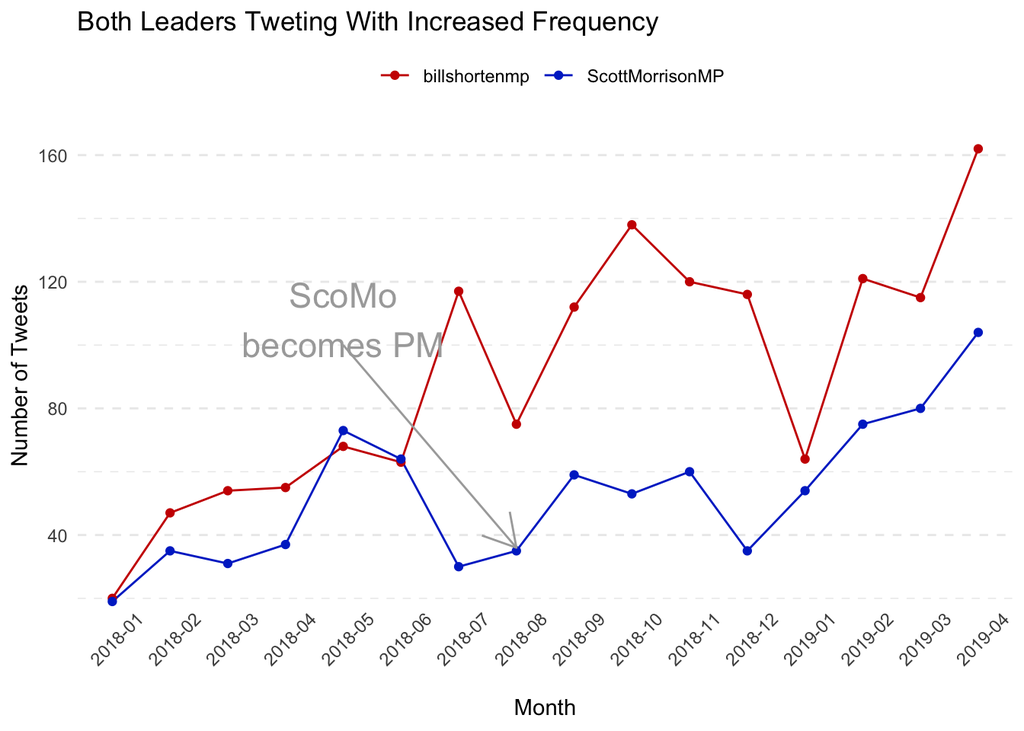

```r
pm_candidate_tweets_clean %>%
  filter(created_year >= 2018, created_yearmon < '2019-05') %>%
  count(screen_name, created_yearmon) %>%
  ggplot(aes(x= created_yearmon, y= n, colour = screen_name, group = screen_name)) +
  geom_line() +
  geom_point() +
  annotate("segment", x='2018-05', xend = '2018-08', y= 100, yend = 36, arrow = arrow(), colour = "darkgrey") +
  annotate("text", x= '2018-05', y= 108, label = "ScoMo\nbecomes PM", size = 6, colour = "darkgrey") +
  scale_colour_manual(values = party_colours, name = "") +
  ggtitle("Both Leaders Tweting With Increased Frequency") +
  labs(y= "Number of Tweets", x= "Month") +
  theme_minimal() +
  theme(axis.text.x = element_text(angle = 45), panel.grid.major.y = element_line(linetype = 2), panel.grid.minor.y = element_line(linetype = 2), panel.grid.major.x = element_blank(), legend.position = "top")
```

Additionally, since the beginning of 2018, ScoMo has only tweeted more than Shorten for the month twice, coming in consecutive months in May and June (in his then capacity as Treasurer, no doubt spruiking that year’s budget).

#### Winner:

**Bill Shorten (Shorten 1, Sco Mo 0)**

## Who’s tweets are more popular?

### Who gets more favourites?

When measuring tweet popularity by the number of *favourites* it receives, Shorten takes the chocolates in this measure, with a median of 536 favourites, to ScoMo’s 325.

ScoMo did the get the two highest favourite counts though, with the following tweet getting 15,936 favourite:

> *The remarks by Senator Fraser Anning blaming the murderous attacks by a violent, right-wing, extremist terrorist in New Zealand on immigration are disgusting. Those views have no place in Australia, let alone the Australian Parliament.*

Who could forget, Senator Anning’s ridiculously insensitive remarks…

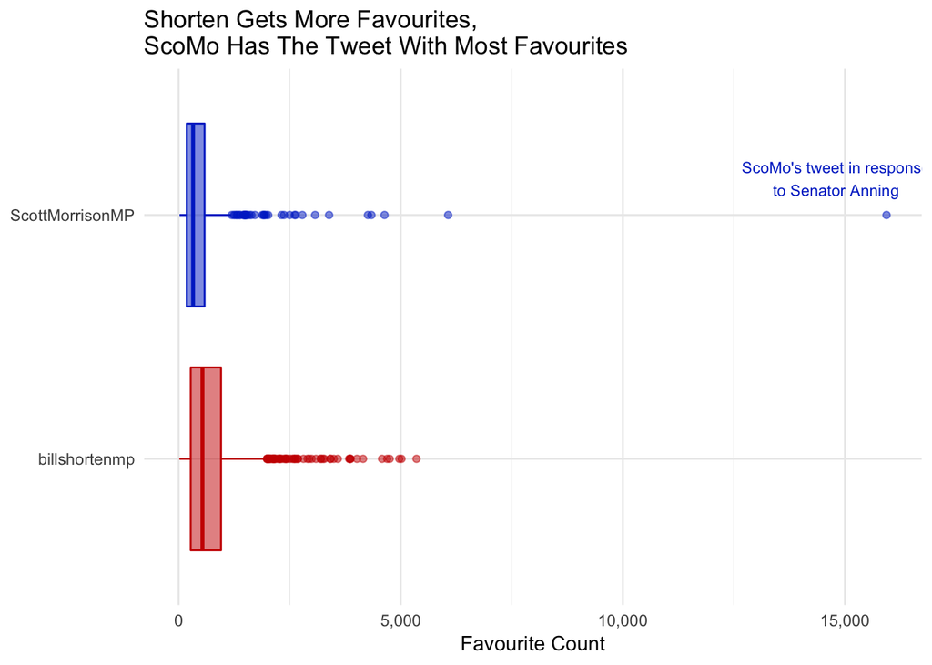

```r
as_leader_tweets %>%
  filter(is_retweet == FALSE) %>%
  ggplot(aes(x= screen_name, y= favorite_count, fill = screen_name, colour = screen_name)) +
  geom_boxplot(alpha = 0.5) +
  annotate("text", x=2.15, y=14800, label = "ScoMo's tweet in response\nto Senator Anning", color = liberals, size =3) +
  scale_fill_manual(values = party_colours) +
  scale_colour_manual(values = party_colours) +
  scale_y_continuous(labels = comma) +
  labs(title = "Shorten Gets More Favourites,\nScoMo Has The Tweet With Most Favourites", y= "Favourite Count") +
  coord_flip() +
  theme_minimal() +
  theme(axis.title.y = element_blank(), legend.position = "none")
```

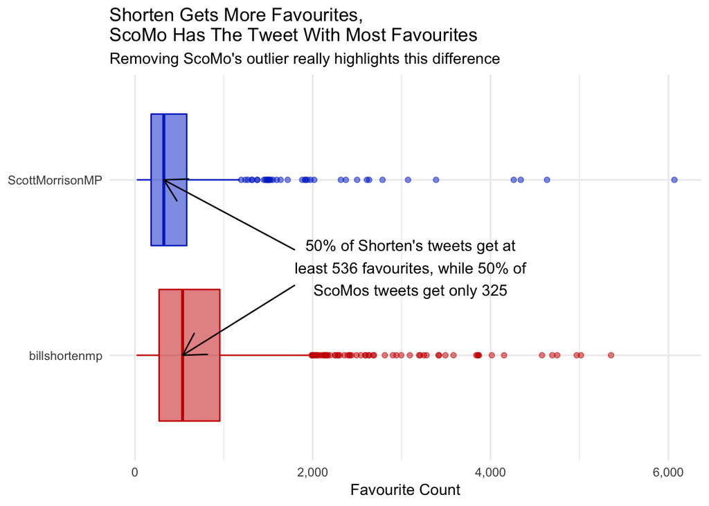

```r
as_leader_tweets %>%
  filter(is_retweet == FALSE, favorite_count < 10000) %>%
  ggplot(aes(x= screen_name, y= favorite_count, fill = screen_name, colour = screen_name)) +
  geom_boxplot(alpha = 0.5) +
  annotate("text", x=1.5, y=3100, label = "50% of Shorten's tweets get at\nleast 536 favourites, while 50% of\nScoMos tweets get only 325") +
  annotate("segment", x=1.6, xend = 2, y=1800, yend = 325, arrow = arrow()) +
  annotate("segment", x=1.4, xend = 1, y=1800, yend = 536, arrow = arrow()) +
  scale_fill_manual(values = party_colours) +
  scale_colour_manual(values = party_colours) +
  scale_y_continuous(labels = comma) +
  labs(title = "Shorten Gets More Favourites,\nScoMo Has The Tweet With Most Favourites",
       subtitle = "Removing ScoMo's outlier really highlights this difference", y= "Favourite Count") +
  coord_flip() +
  theme_minimal() +
  theme(axis.title.y = element_blank(), legend.position = "none")
```

### Who gets retweeted more?

Shorten clearly gets more retweets (median retweet 215.5 to ScoMo’s61). ScoMo’s tweet above about Senator Anning was also the most retweeted tweet. Shorten’s most retweeted tweet was about ScoMo’s school’s cuts:

> Scott Morrison has locked in massive cuts to public schools.No one voted for Morrison’s cuts to public schools, but he’s cutting them anyway. Please share so everyone knows what just happened.

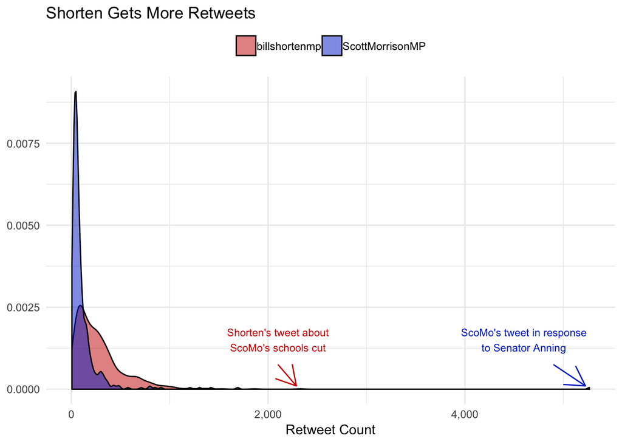

```r
as_leader_tweets %>%
  filter(is_retweet == FALSE) %>%
  ggplot(aes(x= retweet_count, fill = screen_name)) +
  geom_density(alpha = 0.5) +
  scale_fill_manual(values = party_colours) +
  scale_colour_manual(values = party_colours) +
  scale_x_continuous(labels = comma) +
  annotate("text", x=4600, y= 0.0015, label = "ScoMo's tweet in response\nto Senator Anning", color = liberals, size =3) +
  annotate("segment", x= 4900, xend = max(as_leader_tweets$retweet_count[as_leader_tweets$screen_name == "ScottMorrisonMP"]) - 40, y=0.00075, yend = 0.0001, arrow = arrow(), colour = liberals) +
  annotate("text", x=2100, y= 0.0015, label = "Shorten's tweet about\nScoMo's schools cut", color = labor, size =3) +
  annotate("segment", x= 2100, xend = max(as_leader_tweets$retweet_count[as_leader_tweets$screen_name == "billshortenmp"]) - 40, y=0.00075, yend = 0.0001, arrow = arrow(), colour = labor) +
  labs(title = "Shorten Gets More Retweets", x= "Retweet Count") +
  theme_minimal() +
  theme(axis.title.y = element_blank(), legend.position = "top", legend.title = element_blank())
```

#### Winner:

**Bill Shorten (Shorten 2, Sco Mo 0)**

## Who has longer tweets?

Why do I care about this? Well I probably don’t, but maybe it’s a proxy for who provides constituents with greater level of detail… or jargon?

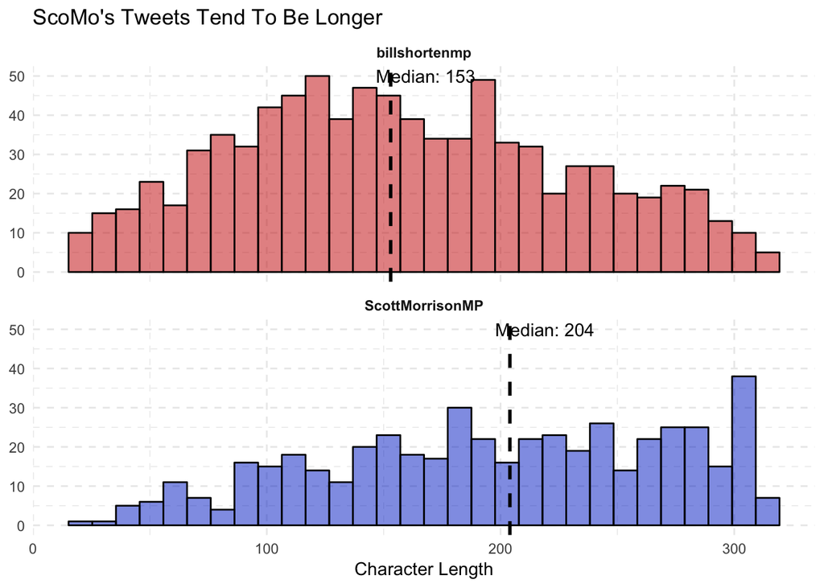

```r
as_leader_tweets <- as_leader_tweets %>%
  mutate(TweetCharacterLength = str_length(text),
         TweetSentencesCount = str_count(text, "[[:alnum:] ][.!?]"),
         TweetWordCount = str_count(text, "[[:alpha:][-]]+"),
         TweetCapitalsCount = str_count(text, "[A-Z]"),
         TweetLettersCount = str_count(text, "[A-Za-z]"),
         TweetPunctuationCount = str_count(text, "[[:punct:]]"),
         TweetExclamationCount = str_count(text, fixed("!")),
         TweetQuestionCount = str_count(text, fixed("?")),
         TweetDigitsCount = str_count(text, "[[:digit:]]"),
         TweetDistinctWordsCount = lengths(lapply(strsplit(text, split = ' '), unique)),
         TweetLexicalDensity = TweetDistinctWordsCount / TweetWordCount)

med_chars <- as_leader_tweets %>%
  filter(is_retweet == FALSE) %>%
  group_by(screen_name) %>%
  summarise(tweet_med_chars = median(TweetCharacterLength)) %>% ungroup()


as_leader_tweets %>%
  filter(is_retweet == FALSE) %>%
  ggplot(aes(x= TweetCharacterLength, fill = screen_name)) +
  geom_histogram(alpha = 0.5, colour = "black") +
  scale_fill_manual(values = party_colours) +
  labs(title = "ScoMo's Tweets Tend To Be Longer", x = "Character Length") +
  facet_wrap(~ screen_name, ncol = 1) +
  theme_minimal() +
  theme(legend.position = "none", axis.title.y = element_blank(), panel.grid = element_line(linetype = 2), strip.text = element_text(face = "bold")) +
  geom_vline(aes(xintercept = tweet_med_chars), data = med_chars, size = 1, linetype = 2) +
  geom_text(aes(x= tweet_med_chars + 15, label = paste0("Median: ", tweet_med_chars)), data = med_chars, y= 50)
```

#### Winner:

**ScoMo (Shorten 2, Sco Mo 1)**

## Who is the king of hashtags?

ScoMo includes a hashtag in over 20% of his tweets. Shorten on the other hand only includes a hashtag in just over 7% of his tweets. Good old hip ScoMo is the newly minted hashtag king!

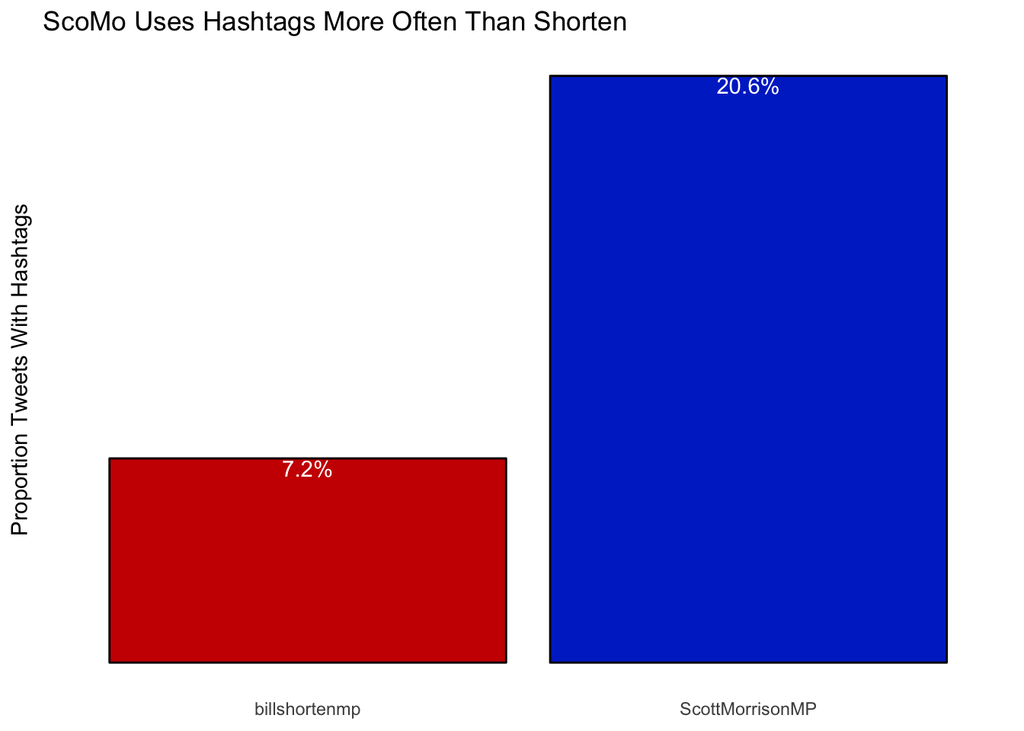

```r
as_leader_tweets %>%
  filter(is_retweet == FALSE) %>%
  mutate(is_hashtag = ifelse(is.na(hashtags), FALSE, TRUE)) %>%
  group_by(screen_name, is_hashtag) %>%
  summarise(n_hashtags = n()) %>%
  mutate(hashtag_proportion = n_hashtags / sum(n_hashtags)) %>%
  filter(is_hashtag == TRUE) %>%
  ggplot(aes(x= screen_name, y= hashtag_proportion, fill = screen_name)) +
  geom_col(colour = "black") +
  geom_text(aes(label = percent(hashtag_proportion)), vjust = 1.1, colour = "white") +
  scale_fill_manual(values = party_colours) +
  scale_y_continuous(labels = percent) +
  labs(title = "ScoMo Uses Hashtags More Often Than Shorten", y= "Proportion Tweets With Hashtags") +
  theme_minimal() +
  theme(panel.grid = element_blank(), axis.title.x = element_blank(), legend.position = "none", axis.text.y = element_blank())
```

#### Winner:

**ScoMo (Shorten 2, Sco Mo 2)**

## Who uses more media (photos, videos)?

The use of media is interesting when it comes to politicians… who doesn’t love a good opportunity to awkwardly shake a few hands or awkwardly kiss a few babies, while the cameras are around?!

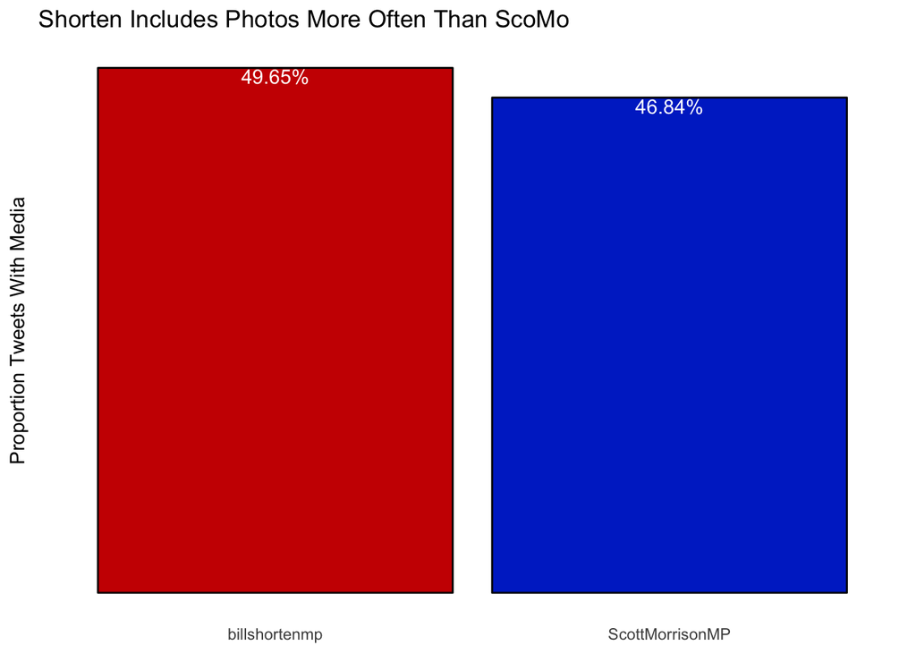

```r
as_leader_tweets %>%
  filter(is_retweet == FALSE) %>%
  mutate(is_media = ifelse(!is.na(media_type), FALSE, TRUE)) %>%
  group_by(screen_name, is_media) %>%
  summarise(n_media = n()) %>%
  mutate(media_proportion = n_media / sum(n_media)) %>%
  filter(is_media == TRUE) %>%
  ggplot(aes(x= screen_name, y= media_proportion, fill = screen_name)) +
  geom_col(colour = "black") +
  geom_text(aes(label = percent(media_proportion)), vjust = 1.1, colour = "white") +
  scale_fill_manual(values = party_colours) +
  scale_y_continuous(labels = percent) +
  labs(title = "Shorten Includes Photos More Often Than ScoMo", y= "Proportion Tweets With Media") +
  theme_minimal() +
  theme(panel.grid = element_blank(), axis.title.x = element_blank(), legend.position = "none", axis.text.y = element_blank())
```

# Tweet Content Analysis

Shorten’s tweets appear to talk about the royal commission (the current one into bank lending I assume since banks also appear) with some frequency, while also mentioning the heart-string items - *cuts*, *schools*, *family*, *medicare*. He also seems to be mentioning his opponent quite frequently.

ScoMo seems to be keeping the content of his tweets focused on the economy, with terms such as *economy*, *jobs*, *businesses*, *budget* and a few hashtags (*strongeraus* and *buildingyoureconomy*) appearing quite frequently.

It will be interesting to measure the sentiment scores of their tweeting behaviour.

[figure not shown]

```r
# function to expand contractions in an English-language source
fix.contractions <- function(doc) {
  # "won't" is a special case as it does not expand to "wo not"
  doc <- gsub("won’t", "will not", doc)
  doc <- gsub("can’t", "can not", doc)
  doc <- gsub("n’t", " not", doc)
  doc <- gsub("’ll", " will", doc)
  doc <- gsub("’re", " are", doc)
  doc <- gsub("’ve", " have", doc)
  doc <- gsub("’m", " am", doc)
  doc <- gsub("’d", " would", doc)
  # 's could be 'is' or could be possessive: it has no expansion
  doc <- gsub("’s", "", doc)
  return(doc)
}


# fix (expand) contractions
as_leader_tweets$text <- sapply(as_leader_tweets$text, fix.contractions)

# dont want to see when either leader has been mention so am taking their twitter handle out
words_to_remove <- c("amp", "scottmorrisonmp", "billshortenmp")

# create a df of unested words (tokens)
tweets_words <- as_leader_tweets %>%
  mutate(text = gsub("https.*$", "", text),
         text = str_remove_all(text, "[:digit:]")) %>%
  select(status_id, screen_name, created_date, created_time, text) %>%
  unnest_tokens(word, text, drop = F) %>%
  anti_join(stop_words, by = "word") %>%
  filter(!word %in% words_to_remove)

# create a df to calculate the proportion (term-frequency) words are used
word_proportion <- tweets_words %>%
  group_by(screen_name, word) %>%
  summarise(n_words = n()) %>% ungroup() %>%
  left_join(as_leader_tweets %>% group_by(screen_name) %>% summarise(n_tweets = n()), by = "screen_name") %>%
  mutate(word_prop = n_words / n_tweets)

# function to plot top 30 words
top_words_plot <- function(df, polly, party) {

  df %>%
    filter(screen_name == polly) %>%
    arrange(desc(word_prop)) %>%
    head(30) %>%
    ggplot(aes(x= reorder(word, word_prop), y= word_prop)) +
    geom_col(fill = party) +
    ggtitle(paste0(polly, "'s 20 Most Frequently Used Words")) +
    geom_text(aes(label = n_words), hjust = 1, colour = "white") +
    scale_y_continuous(labels = percent) +
    coord_flip() +
    theme_minimal() +
    theme(axis.title = element_blank(), panel.grid = element_blank(), panel.grid.major.x = element_line(linetype =2))
}

# create and display multi-plot
sm <- top_words_plot(word_proportion, "ScottMorrisonMP", liberals)
bs <- top_words_plot(word_proportion, "billshortenmp", labor)

gridExtra::grid.arrange(sm, bs, ncol = 2)
```

#### Winner:

**ScoMo (Shorten 2, Sco Mo 3)**

## How often does each leader mention their opponent

Some assumptions needed to be made to determine whether each candidate mentions the oposition in their tweets. If the words “Bill”, “Shorten”, “Labor” or “Opposition” appeared in ScoMo’s tweets, then we say he has mentioned his competitor. On the other hand, if Shorten’s tweets contain any of “Scott”, “Morrisson”, “Liberal”, “Liberals”, then we say that he mentioned his competitor in his tweets.

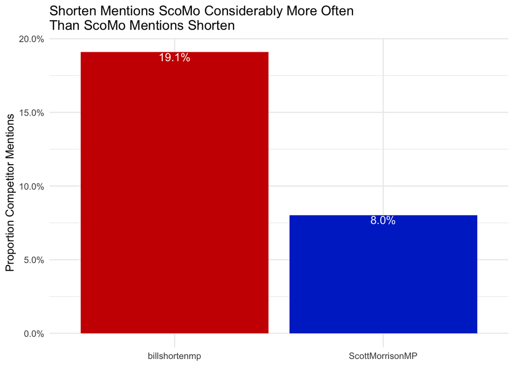

```r
lib_words <- c("labor", "bill", "shorten", "opposition")
lab_words <- c("liberal", "liberals", "scott", "morrison")

tweets_words <- tweets_words %>%
  mutate(is_competitor_mention = ifelse(screen_name == "billshortenmp" & word %in% lab_words, TRUE, ifelse(screen_name == "ScottMorrisonMP" & word %in% lib_words, TRUE, FALSE)))


comp_mention <- tweets_words %>%
  count(status_id, screen_name, is_competitor_mention) %>%
  spread(key = is_competitor_mention, value = n) %>%
  mutate(is_competitor_mention = ifelse(is.na(`TRUE`), FALSE, TRUE)) %>%
  select(status_id, screen_name, is_competitor_mention)


comp_mention %>%
  group_by(screen_name, is_competitor_mention) %>%
  summarise(n_comp_mentions = n()) %>%
  mutate(proportion_comp_mention = n_comp_mentions / sum(n_comp_mentions)) %>%
  filter(is_competitor_mention == TRUE) %>%
  ggplot(aes(x= screen_name, y= proportion_comp_mention, fill = screen_name)) +
  geom_bar(stat = "identity") +
  geom_text(aes(label = percent(proportion_comp_mention)), vjust = 1.1, colour = "white") +
  scale_fill_manual(values = party_colours) +
  scale_y_continuous(labels = percent) +
  labs(title = "Shorten Mentions ScoMo Considerably More Often\nThan ScoMo Mentions Shorten", y= "Proportion Competitor Mentions") +
  theme_minimal() +
  theme(legend.position = "none", axis.title.x = element_blank())
```

#### Winner:

**ScoMo (Shorten 2, Sco Mo 4)**

## Who is the more positive tweeter?

```r
# join on to the afinn lexicon to be able to get a
tweet_sentiment <- tweets_words %>%
  inner_join(get_sentiments("afinn"), by = "word")
```

Using a common lexicon for sentiment analysis created by Finn Årup Nielsen (http://www2.imm.dtu.dk/pubdb/views/publication_details.php?id=6010) called the *AFINN* lexicon, we can measure the positivity of the words contained within each candidate’s tweets.

Using this method, it is clear that ScoMo has been using Twitter to push a more positive message than Shorten, with an overall positivity index of 578 compared to Shorten’s 346

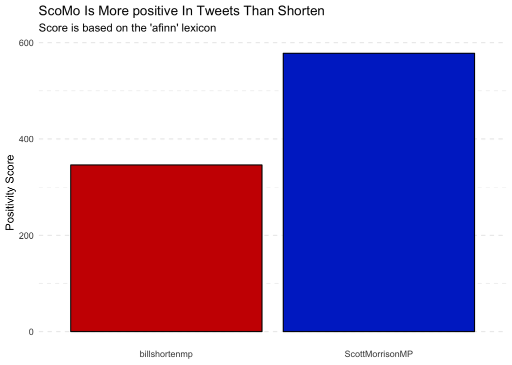

```r
tweet_sentiment %>%
  group_by(screen_name) %>%
  summarise(positivity_index = sum(score)) %>%
  ggplot(aes(x= screen_name, y= positivity_index, fill = screen_name)) +
  geom_bar(stat = "identity", colour = "black") +
  scale_fill_manual(values = party_colours) +
  labs(title = "ScoMo Is More positive In Tweets Than Shorten", subtitle = "Score is based on the 'afinn' lexicon", y= "Positivity Score") +
  theme_minimal() +
  theme(legend.position = "none", axis.title.x = element_blank(), panel.grid = element_line(linetype = 2), panel.grid.major.x = element_blank())
```

When we look at this over time, it’s clear that Shorten has started to tweet with increasing negativity. I wonder if his messaging strategy is to use fear and negativity to get voters to turn out and vote for Labor…

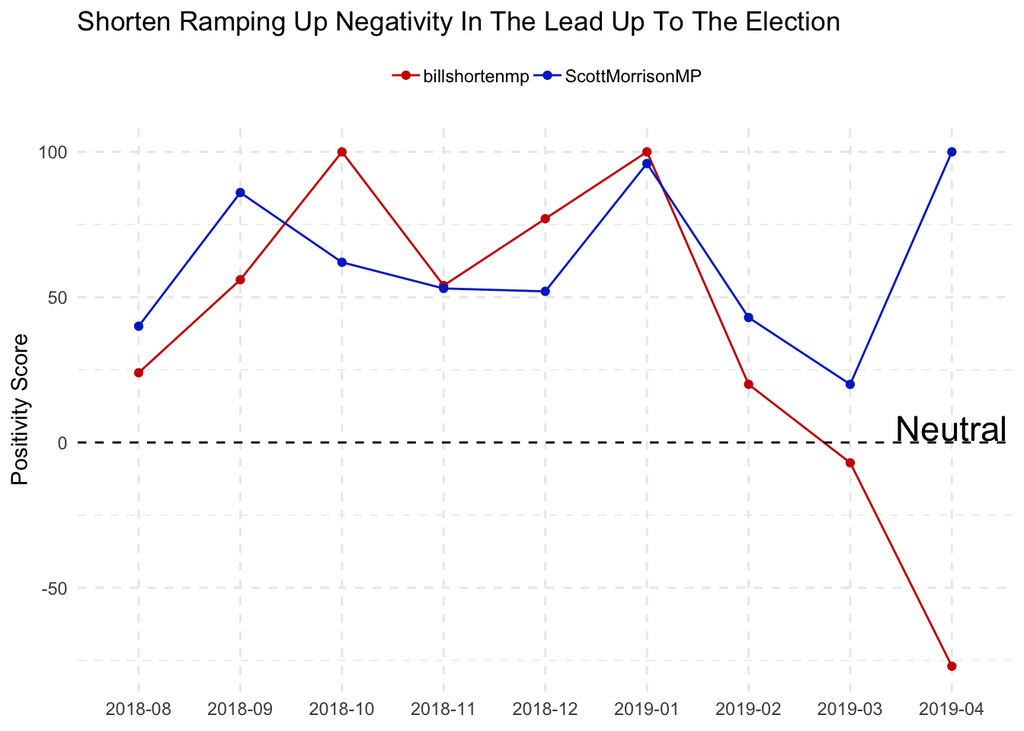

```r
tweet_sentiment %>%
  mutate(created_yearmon = format(as.Date(created_date), "%Y-%m")) %>%
  group_by(screen_name, created_yearmon) %>%
  summarise(positivity_index = sum(score)) %>%
  filter(created_yearmon < '2019-05') %>%
  ggplot(aes(x= created_yearmon, y= positivity_index, colour = screen_name, group = screen_name)) +
  geom_line() +
  geom_point() +
  geom_hline(yintercept = 0, colour = "black", linetype = 2) +
  annotate("text", x= "2019-04", y= 5, label = "Neutral", size = 6) +
  scale_colour_manual(values = party_colours) +
  labs(title = "Shorten Ramping Up Negativity In The Lead Up To The Election", y= "Positivity Score") +
  theme_minimal() +
  theme(legend.position = "top", legend.title = element_blank(), axis.title.x = element_blank(), panel.grid = element_line(linetype = 2))
```

#### Winner:

**ScoMo (Shorten 2, Sco Mo 5)**

# Conclusion

Of the eight questions posed, ScoMo wins five to Shorten’s two from my perspective. The two candidates drew one question. While Shorten tweets more frequently and uses imagery more often, the content of ScoMo’s tweets get him over the line in my 2019 Federal Twitter election.